# هوش مصنوعی - پروژه 5

### سنا ساری نوایی - 810199435

```python
import pandas as pd
import numpy as np
import matplotlib.pyplot as plt
```

# بخش اول: بررسی و پیش پردازش داده

```python
train_label = pd.read_csv('AI-CA5-Dataset/TrainLabels.csv', header = None)
train_img = pd.read_csv('AI-CA5-Dataset/TrainImgs.csv', header = None)
test_label = pd.read_csv('AI-CA5-Dataset/TestLabels.csv', header = None)
test_img = pd.read_csv('AI-CA5-Dataset/TestImgs.csv', header = None)
```

در این قسمت از مجموعه داده train، از هر کلاس، یک داده را انتخاب میکنیم و با تغییر سایز، آن را به همراه شماره کلاس مخصوص به خودش نشان میدهیم.

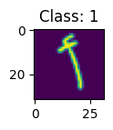

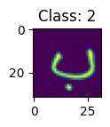

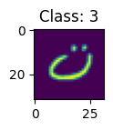

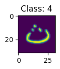

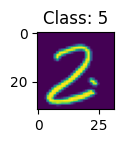

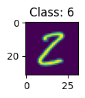

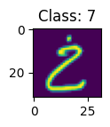

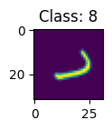

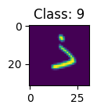

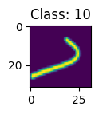

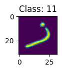

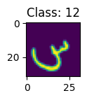

[16 more figures not shown]

```python
rows = train_label.drop_duplicates(0)
for row in rows.itertuples():
    plt.figure(figsize=(1, 1))
    plt.title("Class: " + str(row[1]))
    img = train_img.iloc[row.Index, :].to_numpy().reshape(32,32)
    img = np.transpose(img)
    plt.imshow(img)
    plt.show()
```

برای محاسبه کردن اینکه هر پیکسل در چه محدوده ای قرار میگیرد، مانند سری قبل، از هر کلاس یک داده را انتخاب میکنیم. سپس مقادیر مینیموم و ماکسیمم را برای هرکدام از کلاس ها محاسبه میکنیم و همانطور که در پایین مشخص است، همه پیکسل ها در حدود بازه 0 تا 255 قرار میگیرند.

```python
rows = train_label.drop_duplicates(0)
for row in rows.itertuples():
    img = train_img.iloc[row.Index, :].to_numpy().reshape(32,32)
    img = np.transpose(img)
    print("Minimum pixel of class "+ str(row[1]) + " is " + str(np.amin(img)) + " and Maximum pixel is " + str(np.amax(img)))
```

```
Minimum pixel of class 1 is 0 and Maximum pixel is 255
Minimum pixel of class 2 is 0 and Maximum pixel is 255
Minimum pixel of class 3 is 0 and Maximum pixel is 255
Minimum pixel of class 4 is 0 and Maximum pixel is 255
Minimum pixel of class 5 is 0 and Maximum pixel is 255
Minimum pixel of class 6 is 0 and Maximum pixel is 255
Minimum pixel of class 7 is 0 and Maximum pixel is 255
Minimum pixel of class 8 is 0 and Maximum pixel is 255
Minimum pixel of class 9 is 0 and Maximum pixel is 255
Minimum pixel of class 10 is 0 and Maximum pixel is 255
Minimum pixel of class 11 is 0 and Maximum pixel is 255
Minimum pixel of class 12 is 0 and Maximum pixel is 255
Minimum pixel of class 13 is 0 and Maximum pixel is 255
Minimum pixel of class 14 is 0 and Maximum pixel is 255
Minimum pixel of class 15 is 0 and Maximum pixel is 255
Minimum pixel of class 16 is 0 and Maximum pixel is 255
Minimum pixel of class 17 is 0 and Maximum pixel is 255
Minimum pixel of class 18 is 0 and Maximum pixel is 255
Minimum pixel of class 19 is 0 and Maximum pixel is 255
Minimum pixel of class 20 is 0 and Maximum pixel is 255
Minimum pixel of class 21 is 0 and Maximum pixel is 255
Minimum pixel of class 22 is 0 and Maximum pixel is 255
Minimum pixel of class 23 is 0 and Maximum pixel is 255
Minimum pixel of class 24 is 0 and Maximum pixel is 255
Minimum pixel of class 25 is 0 and Maximum pixel is 255
Minimum pixel of class 26 is 0 and Maximum pixel is 255
Minimum pixel of class 27 is 0 and Maximum pixel is 255
Minimum pixel of class 28 is 0 and Maximum pixel is 255
```

```python
print("Size of train: " + str(train_img.shape[0]))
print("Size of test: " + str(test_img.shape[0]))
print("Class Number: " , rows.shape[0])
```

```
Size of train: 13440
Size of test: 3360
Class Number:  28
```

در این بخش، به ازای همه داده هایی که در train_label و test_label وجود دارند، آنهایی را که کلاس آنها کوچکتر مساوی 16 میباشد را نگه میداریم و بقیه را دور میریزیم. زیرا در ادامه با این 16 کلاس کار میکنیم.

```python
train_data = []
test_data = []
for row in train_label.itertuples():
    if row[1] > 16:
        continue
    train_data.append(train_img.iloc[row.Index, :])
train_df = pd.DataFrame(train_data)

for row in test_label.itertuples():
    if row[1] > 16:
        continue
    test_data.append(test_img.iloc[row.Index, :])
test_df = pd.DataFrame(test_data)
```

در این بخش نیز ابتدا با استفاده از ()len مقدار عددی داده test و train را مشخص میکنیم. سپس به رسم میله ای هردو میپردازیم. داده آموزشی حدود 4 برابر داده آزمایشی میباشد.

```
Size of train data: 7680
Size of test data: 1920
```

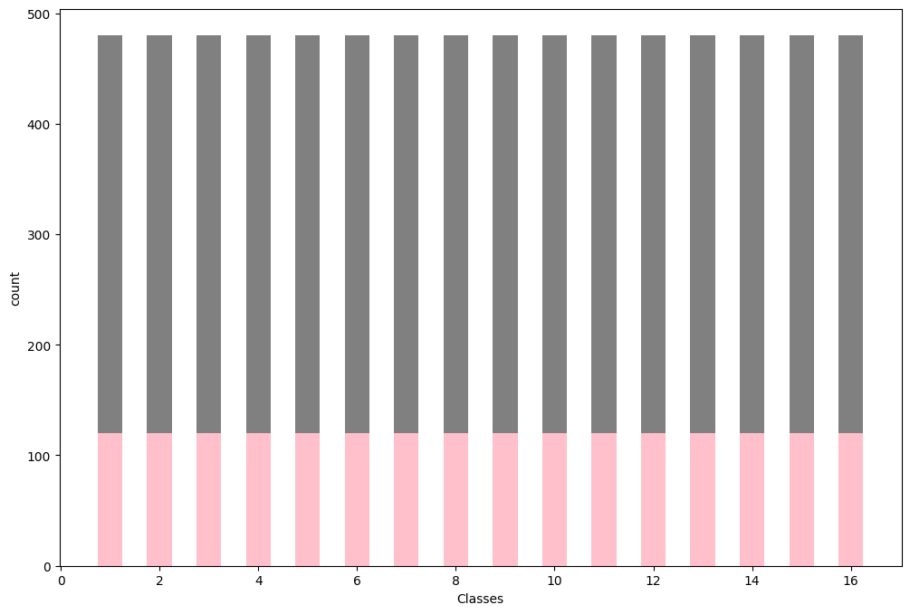

```python
train_label = train_label[train_label[0] <= 16]
test_label = test_label[test_label[0] <= 16]
classNumber_train, train = np.unique(train_label, return_counts = True)
classNumber_test, test = np.unique(test_label, return_counts = True)
print("Size of train data: " + str(len(train_data)))
print("Size of test data: " + str(len(test_data)))
fig = plt.figure(figsize = (12, 8))
plt.bar(classNumber_train, train , width = 0.5, color ='gray')
plt.bar(classNumber_test, test , width = 0.5, color ='pink')
plt.xlabel('Classes')
plt.ylabel('count')
plt.show()
```

برای اینکه مقدار هر پیکسل بین 0 و 1 باشد، کافیست مقدار آن را به 255 تقسیم کنیم. حال به بررسی مزایای scale کردن میپردازیم:

- این کار میتواند از انحراف مقادیر پیکسل ها جلوگیری کند. اگر داده خود را اسکیل نکنیم، محدوده توزیع برای هر ویژگی متفاوت میشود و میزان تغییرات بیشتر از حدی میشود که توقعش را داریم و هندل کردن آن سخت میشود.
- از طرف دیگر scale کردن باعث میشود مقدار میانگین کوچک شود و این امر باعث افزایش سرعت محاسبات میگردد.
- فایده دیگر آن است که این کار برای کاهش احتمال ناپدید شدن گرادیان مفید است. یعنی میتوانیم شبکه های عمیقتری را جست و جو کنیم.

```python
train_df = train_df / 255
test_df = test_df / 255
```

```python
onehot_vectors = np.zeros((train_label[0].size, 16))
for i in range(train_label[0].size):
    onehot_vectors[i, train_label.iloc[i, 0]-1] = 1
onehot_vectors = pd.DataFrame(onehot_vectors)
onehot_vectors
```

|  | 0 | 1 | 2 | 3 | 4 | 5 | 6 | 7 | 8 | 9 | 10 | 11 | 12 | 13 | 14 | 15 |
| --- | --- | --- | --- | --- | --- | --- | --- | --- | --- | --- | --- | --- | --- | --- | --- | --- |
| 0 | 1.0 | 0.0 | 0.0 | 0.0 | 0.0 | 0.0 | 0.0 | 0.0 | 0.0 | 0.0 | 0.0 | 0.0 | 0.0 | 0.0 | 0.0 | 0.0 |
| 1 | 1.0 | 0.0 | 0.0 | 0.0 | 0.0 | 0.0 | 0.0 | 0.0 | 0.0 | 0.0 | 0.0 | 0.0 | 0.0 | 0.0 | 0.0 | 0.0 |
| 2 | 1.0 | 0.0 | 0.0 | 0.0 | 0.0 | 0.0 | 0.0 | 0.0 | 0.0 | 0.0 | 0.0 | 0.0 | 0.0 | 0.0 | 0.0 | 0.0 |
| 3 | 1.0 | 0.0 | 0.0 | 0.0 | 0.0 | 0.0 | 0.0 | 0.0 | 0.0 | 0.0 | 0.0 | 0.0 | 0.0 | 0.0 | 0.0 | 0.0 |
| 4 | 1.0 | 0.0 | 0.0 | 0.0 | 0.0 | 0.0 | 0.0 | 0.0 | 0.0 | 0.0 | 0.0 | 0.0 | 0.0 | 0.0 | 0.0 | 0.0 |
| ... | ... | ... | ... | ... | ... | ... | ... | ... | ... | ... | ... | ... | ... | ... | ... | ... |
| 7675 | 0.0 | 0.0 | 0.0 | 0.0 | 0.0 | 0.0 | 0.0 | 0.0 | 0.0 | 0.0 | 0.0 | 0.0 | 0.0 | 0.0 | 0.0 | 1.0 |
| 7676 | 0.0 | 0.0 | 0.0 | 0.0 | 0.0 | 0.0 | 0.0 | 0.0 | 0.0 | 0.0 | 0.0 | 0.0 | 0.0 | 0.0 | 0.0 | 1.0 |
| 7677 | 0.0 | 0.0 | 0.0 | 0.0 | 0.0 | 0.0 | 0.0 | 0.0 | 0.0 | 0.0 | 0.0 | 0.0 | 0.0 | 0.0 | 0.0 | 1.0 |
| 7678 | 0.0 | 0.0 | 0.0 | 0.0 | 0.0 | 0.0 | 0.0 | 0.0 | 0.0 | 0.0 | 0.0 | 0.0 | 0.0 | 0.0 | 0.0 | 1.0 |
| 7679 | 0.0 | 0.0 | 0.0 | 0.0 | 0.0 | 0.0 | 0.0 | 0.0 | 0.0 | 0.0 | 0.0 | 0.0 | 0.0 | 0.0 | 0.0 | 1.0 |

7680 rows × 16 columns

# بخش دوم: تکمیل بخش های ناقص شبکه عصبی

# Dataloader

```python
class Dataloader:
    def __init__(self, data, labels, n_classes, batch_size=None, shuffle=False):
        assert len(data)==len(labels)
        self.__n_classes = n_classes
        self.__batch_size = batch_size
        self.__shuffle = shuffle
        self.__data = data
        self.__onehot_labels = self.__onehot(labels, self.__n_classes)

    def __onehot(self, labels, n_classes):
        onehot_vectors = np.zeros((labels.size, n_classes))
        for i in range(labels.size):
            onehot_vectors[i, labels.iloc[i, 0]-1] = 1
        return onehot_vectors

    def __shuffle_dataset(self):
        random_permutation = np.random.permutation(len(self.__data))
        self.__onehot_labels = self.__onehot_labels[random_permutation]
        self.__data = self.__data.iloc[random_permutation]

    def __iter__(self):
        if self.__shuffle:
            self.__shuffle_dataset()

        if self.__batch_size==None:
            yield (np.matrix(self.__data), np.matrix(self.__onehot_labels))
            return

        for idx in range(0, len(self.__data), self.__batch_size):
            yield (np.matrix(self.__data[idx:idx+self.__batch_size]),
                   np.matrix(self.__onehot_labels[idx:idx+self.__batch_size]))
```

# Activation Functions

```python
class Identical:
    def __init__(self): pass

    def __val(self, matrix):
        identical_value = np.matrix(matrix, dtype=float)
        return identical_value

    def derivative(self, matrix):
        temp = np.matrix(matrix, dtype=float)
        identical_derivative = np.matrix(np.full(np.shape(temp), 1.))
        return identical_derivative

    def __call__(self, matrix):
        return self.__val(matrix)


class Relu:
    def __init__(self): pass

    def __val(self, matrix):
        relu_value = np.matrix(matrix, dtype=float)
        relu_value = np.maximum(0, relu_value)
        return relu_value

    def derivative(self, matrix):
        relu_derivative = np.matrix(matrix, dtype=float)
        relu_derivative[relu_derivative >= 0] = 1
        relu_derivative = np.maximum(0, relu_derivative)
        return relu_derivative

    def __call__(self, matrix):
        return self.__val(matrix)


class LeakyRelu:
    def __init__(self, negative_slope=0.01):
        self.negative_slope = negative_slope

    def __val(self, matrix):
        leacky_relu_value = np.matrix(matrix, dtype=float)
        leacky_relu_value = np.where(matrix > 0, matrix, matrix * self.negative_slope)
        return leacky_relu_value

    def derivative(self, matrix):
        leacky_relu_derivative = np.matrix(matrix, dtype=float)
        leacky_relu_derivative[leacky_relu_derivative > 0] = 1
        leacky_relu_derivative[leacky_relu_derivative <= 0] = self.negative_slope
        return leacky_relu_derivative

    def __call__(self, matrix):
        return self.__val(matrix)


class Sigmoid:
    def __init__(self): pass

    def __val(self, matrix):
        sigmoid_value = np.matrix(1.0 / (1.0 + np.exp(-matrix)), dtype = float)
        return sigmoid_value

    def derivative(self, matrix):
        value = self.__val(matrix)
        sigmoid_derivative = np.multiply(value, np.matrix(1 - value))
        return sigmoid_derivative

    def __call__(self, matrix):
        return self.__val(matrix)


class Softmax:
    def __init__(self): pass

    def __val(self, matrix):
        softmax_temp = np.matrix(matrix, dtype=float)
        softmax_value = np.exp(softmax_temp - np.max(softmax_temp))
        softmax_value /= softmax_value.sum(axis=1)
        return softmax_value

    def __call__(self, matrix):
        return self.__val(matrix)

class Tanh:

    def __init__(self): pass

    def __val(self, matrix):
        tanh_value = np.tanh(matrix)
        tanh_value = np.matrix(tanh_value, dtype=float)
        return tanh_value

    def derivative(self, matrix):
        tanh_derivative = 1 - np.power(self.__val(matrix), 2)
        return tanh_derivative

    def __call__(self, matrix):
        return self.__val(matrix)
```

# Loss Function

```python
class CrossEntropy: #(with softmax)
    def __init__(self): pass

    def __val(self, true_val, expected_val):
        assert np.shape(true_val)==np.shape(expected_val)
        expected_val_mat = np.matrix(expected_val, dtype=float)
        true_val_mat = np.matrix(true_val, dtype=float)
        S = Softmax()(true_val_mat + 1e-8)
        cross_entropy_value = np.sum(-np.multiply(expected_val_mat, np.log(S + 1e-8)), axis=1)
        return cross_entropy_value

    def derivative(self, true_val, expected_val):
        assert np.shape(true_val)==np.shape(expected_val)
        expected_val_mat = np.matrix(expected_val, dtype=float)
        true_val_mat = np.matrix(true_val, dtype=float)
        S = Softmax()
        cross_entropy_derivative = S(true_val_mat) - expected_val_mat
        return cross_entropy_derivative

    def __call__(self, true_val, expected_val):
        return self.__val(true_val, expected_val)
```

# Layer

```python
class Layer:
    DEFAULT_LOW, DEFAULT_HIGH, DEFAULT_MEAN, DEFAULT_VAR = 0, 0.05, 0., 1.

    def __init__(self, input_size, output_size, activation=Identical(), initial_weight='uniform',
                 **initializing_parameters):
        assert type(initial_weight)==str, 'Undefined activation function!'

        self.__weight_initializer_dict = {'uniform':self.__uniform_weight, 'normal':self.__normal_weight}

        assert initial_weight in self.__weight_initializer_dict, 'Undefined weight initialization function!'

        self.__n_neurons = output_size
        weight_initializer = self.__weight_initializer_dict[initial_weight]
        self.__weight = weight_initializer(input_size, self.__n_neurons, **initializing_parameters)
        self.__bias = weight_initializer(1, self.__n_neurons, **initializing_parameters)
        self.__activation = activation

        self.__last_input = None
        self.__last_activation_input = None
        self.__last_activation_output = None
        self.__last_activation_derivative = None

    def forward(self, layer_input):
        assert np.ndim(layer_input)==2
        assert np.size(self.__weight,0) == np.size(layer_input,1)
        self.__last_input = layer_input
        self.__last_activation_input = np.matmul(layer_input, self.__weight) + self.__bias
        self.__last_activation_output = self.__activation(self.__last_activation_input)
        self.__last_activation_derivative = self.__activation.derivative(self.__last_activation_input)
        return self.__last_activation_output

    def update_weights(self, backprop_tensor, lr):
        assert np.ndim(backprop_tensor)==2
        assert np.size(backprop_tensor,0) == np.size(self.__last_activation_derivative,0)
        assert np.size(backprop_tensor,1) == self.__n_neurons
        dldy = np.multiply(backprop_tensor, self.__last_activation_derivative)
        dldw = np.matmul(self.__last_input.transpose(), dldy)
        ones_mat = np.matrix(np.ones(dldy.shape[0]))
        dldb = np.matmul(ones_mat, dldy)
        backprop_tensor = np.matmul(dldy, self.__weight.transpose())
        self.__weight -= lr * dldw
        self.__bias -= lr * dldb
        return backprop_tensor

    def __uniform_weight(self, dim1, dim2, **initializing_parameters):
        low, high = self.DEFAULT_LOW, self.DEFAULT_HIGH
        if 'low' in initializing_parameters.keys(): low = initializing_parameters['low']
        if 'high' in initializing_parameters.keys(): high = initializing_parameters['high']
        weights = np.random.uniform(low, high, size = (dim1, dim2))
        return weights

    def __normal_weight(self, dim1, dim2, **initializing_parameters):
        mean, var = self.DEFAULT_MEAN, self.DEFAULT_VAR
        if 'mean' in initializing_parameters.keys(): mean = initializing_parameters['mean']
        if 'var' in initializing_parameters.keys(): var = initializing_parameters['var']
        weights = np.random.normal(mean, np.sqrt(var), size = (dim1, dim2))
        return weights

    @property
    def n_neurons(self): return self.__n_neurons

    @property
    def weight(self): return self.__weight

    @property
    def bias(self): return self.__bias

    @property
    def activation(self): return self.__activation
```

# Feed Forward Neural Network

```python
class FeedForwardNN:
    def __init__(self, input_shape):
        self.__input_shape = input_shape
        self.__output_shape = None
        self.__layers_list = []
        self.__lr = None
        self.__loss = None

    def add_layer(self, n_neurons, activation=Relu(), initial_weight='uniform', **initializing_parameters):
        assert type(n_neurons)==int, "Invalid number of neurons for the layer!"
        assert n_neurons>0, "Invalid number of neurons for the layer!"

        n_prev_neurons = self.__input_shape if len(self.__layers_list)==0 else self.__layers_list[-1].n_neurons
        new_layer = Layer(n_prev_neurons, n_neurons, activation, initial_weight, **initializing_parameters)
        self.__layers_list.append(new_layer)
        self.__output_shape = self.__layers_list[-1].n_neurons

    def set_training_param(self, loss=CrossEntropy(), lr=1e-3):
        assert self.__layers_list, "Uncomplete model!"
        self.__loss = loss
        self.__lr = lr

    def forward(self, network_input):
        assert type(self.__output_shape) != None, "Model is not compiled!"
        network_output = network_input
        for i in range(len(self.__layers_list)):
            network_output = self.__layers_list[i].forward(network_output)
        return network_output


    def fit(self, epochs, trainloader, testloader=None, print_results=True):
        assert type(self.__output_shape) != None, "Model is not compiled!"
        assert type(self.__lr) != None and type(self.__loss) != None, "Training paramenters are not set!"

        log = {"train_accuracy":[], "train_loss":[], "test_accuracy":[], "test_loss":[]}

        for epoch in range(1, epochs+1):

            if print_results:
                print('Epoch {}:'.format(epoch))

            average_accuracy, average_loss = self.__train(trainloader)
            log['train_accuracy'].append(average_accuracy)
            log['train_loss'].append(average_loss)
            if print_results:
                print('\tTrain: Average Accuracy: {}\tAverage Loss: {}'.format(average_accuracy, average_loss))

            if type(testloader) != type(None):
                average_accuracy, average_loss = self.__test(testloader)
                log['test_accuracy'].append(average_accuracy)
                log['test_loss'].append(average_loss)
                if print_results:
                    print('\tTest: Average Accuracy: {}\tAverage Loss: {}'.format(average_accuracy, average_loss))

        return log


    def __train(self, trainloader):
        bach_accuracies, batch_losses = [], []
        for x_train, y_train in trainloader:
            batch_accuracy, batch_loss = self.__train_on_batch(x_train, y_train)
            bach_accuracies.append(batch_accuracy)
            batch_losses.append(batch_loss)
        return np.mean(bach_accuracies), np.mean(batch_losses)


    def __test(self, testloader):
        bach_accuracies, batch_losses = [], []
        for x_test, y_test in testloader:
            batch_accuracy, batch_loss = self.__test_on_batch(x_test, y_test)
            bach_accuracies.append(batch_accuracy)
            batch_losses.append(batch_loss)
        return np.mean(bach_accuracies), np.mean(batch_losses)


    def __train_on_batch(self, x_batch, y_batch):
        out = self.forward(x_batch)
        self.__update_weights(out, y_batch)
        batch_accuracy = self.__compute_accuracy(out, y_batch)
        batch_average_loss = np.mean(self.__loss(out, y_batch))
        return (batch_accuracy, batch_average_loss)


    def __test_on_batch(self, x_batch, y_batch):
        out = self.forward(x_batch)
        batch_accuracy = self.__compute_accuracy(out, y_batch)
        batch_average_loss = np.mean(self.__loss(out, y_batch))
        return (batch_accuracy, batch_average_loss)


    def __get_labels(self, outputs):
        labels = outputs.argmax(axis = 1)
        return labels


    def __compute_accuracy(self, output, expected_output):
        true_detected = 0
        for i in range(len(output)):
            if self.__get_labels(output[i]) == self.__get_labels(expected_output[i]):
                true_detected += 1
        accuracy = true_detected/len(output) * 100
        return accuracy


    def __update_weights(self, output, y_train):
        length = len(self.__layers_list)
        backPro = self.__layers_list[length-1].update_weights(self.__loss.derivative(output, y_train), self.__lr)
        for i in reversed(range(length-1)):
            backPro = self.__layers_list[i].update_weights(backPro, self.__lr)
        return
```

# بخش سوم: طبقه بندی داده ها

## قسمت اول)آموزش شبکه

```python
INPUT_SHAPE = 1024
LEARNING_RATE = 0.005
EPOCHS = 100
TRAINLOADER = Dataloader(train_df, train_label, 16, 32, shuffle = False)
TESTLOADER = Dataloader(test_df, test_label, 16, 32, shuffle = False)

network = FeedForwardNN(INPUT_SHAPE)
network.add_layer(80, input_shape=INPUT_SHAPE, activation=Relu(), initial_weight='uniform')
network.add_layer(16, activation=Identical(), initial_weight='uniform')
network.set_training_param(loss=CrossEntropy(), lr=LEARNING_RATE)

log = network.fit(EPOCHS, TRAINLOADER, TESTLOADER)
```

```
Epoch 1:
	Train: Average Accuracy: 11.393229166666666	Average Loss: 2.8036071166815826
	Test: Average Accuracy: 30.260416666666668	Average Loss: 2.106371153343533
Epoch 2:
	Train: Average Accuracy: 31.184895833333332	Average Loss: 1.9433583886876238
	Test: Average Accuracy: 37.604166666666664	Average Loss: 1.7387579221400402
Epoch 3:
	Train: Average Accuracy: 41.09375	Average Loss: 1.6244590599889526
	Test: Average Accuracy: 43.645833333333336	Average Loss: 1.554805096554293
Epoch 4:
	Train: Average Accuracy: 47.669270833333336	Average Loss: 1.42080231689512
	Test: Average Accuracy: 48.28125	Average Loss: 1.4291108598417543
Epoch 5:
	Train: Average Accuracy: 52.3828125	Average Loss: 1.2850829721252883
	Test: Average Accuracy: 50.260416666666664	Average Loss: 1.346443935575084
Epoch 6:
	Train: Average Accuracy: 56.171875	Average Loss: 1.1810357187426486
	Test: Average Accuracy: 53.333333333333336	Average Loss: 1.2733267791747873
Epoch 7:
	Train: Average Accuracy: 59.296875	Average Loss: 1.086811907543454
	Test: Average Accuracy: 55.729166666666664	Average Loss: 1.2148067172919235
Epoch 8:
	Train: Average Accuracy: 62.526041666666664	Average Loss: 1.0005405413852324
	Test: Average Accuracy: 57.65625	Average Loss: 1.1735583029412735
Epoch 9:
	Train: Average Accuracy: 65.84635416666667	Average Loss: 0.9201195603772155
	Test: Average Accuracy: 60.15625	Average Loss: 1.1340769838695952
Epoch 10:
	Train: Average Accuracy: 68.046875	Average Loss: 0.8541884718654009
	Test: Average Accuracy: 61.614583333333336	Average Loss: 1.1003005114790652
Epoch 11:
	Train: Average Accuracy: 70.48177083333333	Average Loss: 0.8012491127641564
	Test: Average Accuracy: 62.239583333333336	Average Loss: 1.079099138766172
Epoch 12:
	Train: Average Accuracy: 72.4609375	Average Loss: 0.7526717648749419
	Test: Average Accuracy: 62.760416666666664	Average Loss: 1.066916261906371
Epoch 13:
	Train: Average Accuracy: 74.27083333333333	Average Loss: 0.7079317750561606
	Test: Average Accuracy: 63.75	Average Loss: 1.050052772036516
Epoch 14:
```

[output cut: 245 more lines]

```
Epoch 96:
	Train: Average Accuracy: 99.98697916666667	Average Loss: 0.013849790542667864
	Test: Average Accuracy: 72.76041666666667	Average Loss: 1.441920308887631
Epoch 97:
	Train: Average Accuracy: 99.98697916666667	Average Loss: 0.013559337319975802
	Test: Average Accuracy: 72.76041666666667	Average Loss: 1.445437901914287
Epoch 98:
	Train: Average Accuracy: 99.98697916666667	Average Loss: 0.013268756398479608
	Test: Average Accuracy: 72.70833333333333	Average Loss: 1.4487984168223946
Epoch 99:
	Train: Average Accuracy: 99.98697916666667	Average Loss: 0.012977416413902345
	Test: Average Accuracy: 72.70833333333333	Average Loss: 1.4520792077471918
Epoch 100:
	Train: Average Accuracy: 99.98697916666667	Average Loss: 0.012723507919847016
	Test: Average Accuracy: 72.76041666666667	Average Loss: 1.4551513787147097
```

## قسمت دوم)وزن‌دهی شبکه

اگر مجموعه ای از وزن ها را در شبکه عصبی صفر کنیم، در این صورت تمام سلول های عصبی در هر لایه شروع به تولید همان خروجی و شیب های یکسان میکنند زیرا مشتق ثابت باقی میماند. در نتیجه شبکه عصبی نمیتواند چیزی یاد بگیرد زیرا هیچ منبع عدم تقارن بین نورون های مختلف وجود ندارد. اگر وزن ها با یک مقدار ثابت مقداردهی اولیه شوند نیز همین مسئله رخ میدهد. بنابراین ما هنگام مقداردهی اولیه وزنها در شبکه عصبی، آن را تصادفی انتخاب میکنیم.

## قسمت سوم)تاثیر learning rate

وقتی ما learining rate را پایین می آوریم دقتمان به ازای همان تعداد epoch، کاهش پیدا می کند و وقتی آن را زیاد میکنیم مشاهده میشود که عملکرد Relu کم می شود. با کم کردن learining rate، آموزش مدل آهسته میشود زیرا تغییرات کوچکی در وزن ایجاد میشود. این به این دلیل است که اندازه گام ما که تحت معادله گرادیان نزولی کنترل می شود کم می باشد. ممکن است قبل از رسیدن به حداقل خطا، تکرارهای زیادی طول بکشد. و همچنین ریسک همگرایی در میینموم محلی بالا میرود. بنابراین learining rate بسیار پایین خوب نیست.  
اگر learining rate بیش از حد بزرگ باشد، این امر باعث عملکرد واگرایی نامطلوب در تابع خطا به دلیل تغییرات زیاد در وزن ها و همچنین به دلیل مقدار بزرگتر اندازه گام می شود. ممکن است همگرا نشود یا حتی واگرایی کند. بنابراین learining rate بالا نیز خوب نمیباشد و در ادامه با همان مقدار 0.005 ادامه میدهیم.

learining rate = 0.0005

```python
INPUT_SHAPE = 1024
LEARNING_RATE = 0.0005
EPOCHS = 100
TRAINLOADER = Dataloader(train_df, train_label, 16, 32, shuffle = False)
TESTLOADER = Dataloader(test_df, test_label, 16, 32, shuffle = False)

network = FeedForwardNN(INPUT_SHAPE)
network.add_layer(80, input_shape=INPUT_SHAPE, activation=Relu(), initial_weight='uniform')
network.add_layer(16, activation=Identical(), initial_weight='uniform')
network.set_training_param(loss=CrossEntropy(), lr=LEARNING_RATE)

log = network.fit(EPOCHS, TRAINLOADER, TESTLOADER)
```

```
Epoch 1:
	Train: Average Accuracy: 1.5234375	Average Loss: 2.945195211662508
	Test: Average Accuracy: 6.25	Average Loss: 2.728832671825763
Epoch 2:
	Train: Average Accuracy: 3.2942708333333335	Average Loss: 2.8458947525600764
	Test: Average Accuracy: 6.875	Average Loss: 2.6130755521081057
Epoch 3:
	Train: Average Accuracy: 9.596354166666666	Average Loss: 2.650484950572269
	Test: Average Accuracy: 14.739583333333334	Average Loss: 2.418155864518764
Epoch 4:
	Train: Average Accuracy: 15.442708333333334	Average Loss: 2.4447610120303525
	Test: Average Accuracy: 24.166666666666668	Average Loss: 2.258416873321442
Epoch 5:
	Train: Average Accuracy: 23.697916666666668	Average Loss: 2.2773424092959886
	Test: Average Accuracy: 29.53125	Average Loss: 2.1123269819537898
Epoch 6:
	Train: Average Accuracy: 30.4296875	Average Loss: 2.12913414313103
	Test: Average Accuracy: 34.21875	Average Loss: 1.9927757826660322
Epoch 7:
	Train: Average Accuracy: 34.4921875	Average Loss: 2.0137888500278676
	Test: Average Accuracy: 37.1875	Average Loss: 1.904024393201875
Epoch 8:
	Train: Average Accuracy: 37.838541666666664	Average Loss: 1.927241782942408
	Test: Average Accuracy: 39.635416666666664	Average Loss: 1.8366619296738294
Epoch 9:
	Train: Average Accuracy: 39.466145833333336	Average Loss: 1.8596845853053996
	Test: Average Accuracy: 41.40625	Average Loss: 1.7835312946767314
Epoch 10:
	Train: Average Accuracy: 41.4453125	Average Loss: 1.8045451552607734
	Test: Average Accuracy: 42.552083333333336	Average Loss: 1.740071919682773
Epoch 11:
	Train: Average Accuracy: 42.799479166666664	Average Loss: 1.7578428254252023
	Test: Average Accuracy: 43.958333333333336	Average Loss: 1.7031267570505975
Epoch 12:
	Train: Average Accuracy: 44.244791666666664	Average Loss: 1.7169068936303442
	Test: Average Accuracy: 44.635416666666664	Average Loss: 1.6706701108986073
Epoch 13:
	Train: Average Accuracy: 45.5078125	Average Loss: 1.6798875302420868
	Test: Average Accuracy: 45.833333333333336	Average Loss: 1.6413429328547053
Epoch 14:
```

[output cut: 245 more lines]

```
Epoch 96:
	Train: Average Accuracy: 81.41927083333333	Average Loss: 0.5840984766870024
	Test: Average Accuracy: 66.71875	Average Loss: 0.9338867499270002
Epoch 97:
	Train: Average Accuracy: 81.73177083333333	Average Loss: 0.5779471190649216
	Test: Average Accuracy: 66.71875	Average Loss: 0.9319698552056749
Epoch 98:
	Train: Average Accuracy: 81.953125	Average Loss: 0.5719078982983274
	Test: Average Accuracy: 66.66666666666667	Average Loss: 0.9301942561563666
Epoch 99:
	Train: Average Accuracy: 82.20052083333333	Average Loss: 0.5659519824147399
	Test: Average Accuracy: 66.5625	Average Loss: 0.9284176252659874
Epoch 100:
	Train: Average Accuracy: 82.44791666666667	Average Loss: 0.5599853618086593
	Test: Average Accuracy: 66.61458333333333	Average Loss: 0.9267135100364693
```

learining rate = 0.03

```python
INPUT_SHAPE = 1024
LEARNING_RATE = 0.03
EPOCHS = 100
TRAINLOADER = Dataloader(train_df, train_label, 16, 32, shuffle = False)
TESTLOADER = Dataloader(test_df, test_label, 16, 32, shuffle = False)

network = FeedForwardNN(INPUT_SHAPE)
network.add_layer(80, input_shape=INPUT_SHAPE, activation=Relu(), initial_weight='uniform')
network.add_layer(16, activation=Identical(), initial_weight='uniform')
network.set_training_param(loss=CrossEntropy(), lr=LEARNING_RATE)

log = network.fit(EPOCHS, TRAINLOADER, TESTLOADER)
```

```
Epoch 1:
	Train: Average Accuracy: 0.013020833333333334	Average Loss: 2.9313342824321866
	Test: Average Accuracy: 6.25	Average Loss: 2.775046652227135
Epoch 2:
	Train: Average Accuracy: 0.013020833333333334	Average Loss: 2.8656165469201076
	Test: Average Accuracy: 6.25	Average Loss: 2.7749929982735813
Epoch 3:
	Train: Average Accuracy: 0.013020833333333334	Average Loss: 2.8654697887500715
	Test: Average Accuracy: 6.25	Average Loss: 2.774977197532343
Epoch 4:
	Train: Average Accuracy: 0.013020833333333334	Average Loss: 2.8654265878563097
	Test: Average Accuracy: 6.25	Average Loss: 2.7749774666790197
Epoch 5:
	Train: Average Accuracy: 0.013020833333333334	Average Loss: 2.8654056865772417
	Test: Average Accuracy: 6.25	Average Loss: 2.7749790635580327
Epoch 6:
	Train: Average Accuracy: 0.013020833333333334	Average Loss: 2.865390197123607
	Test: Average Accuracy: 6.25	Average Loss: 2.7749773356564225
Epoch 7:
	Train: Average Accuracy: 0.013020833333333334	Average Loss: 2.8653737873078655
	Test: Average Accuracy: 6.25	Average Loss: 2.774977105762791
Epoch 8:
	Train: Average Accuracy: 0.013020833333333334	Average Loss: 2.865359531608973
	Test: Average Accuracy: 6.25	Average Loss: 2.7749774103040936
Epoch 9:
	Train: Average Accuracy: 0.013020833333333334	Average Loss: 2.865350115922875
	Test: Average Accuracy: 6.25	Average Loss: 2.774977945646908
Epoch 10:
	Train: Average Accuracy: 0.013020833333333334	Average Loss: 2.865341690011767
	Test: Average Accuracy: 6.25	Average Loss: 2.7749771705405832
Epoch 11:
	Train: Average Accuracy: 0.013020833333333334	Average Loss: 2.8653336273711565
	Test: Average Accuracy: 6.25	Average Loss: 2.7749773681335292
Epoch 12:
	Train: Average Accuracy: 0.013020833333333334	Average Loss: 2.865327132251366
	Test: Average Accuracy: 6.25	Average Loss: 2.7749769812702385
Epoch 13:
	Train: Average Accuracy: 0.013020833333333334	Average Loss: 2.8653217606298984
	Test: Average Accuracy: 6.25	Average Loss: 2.774977048071835
Epoch 14:
```

[output cut: 245 more lines]

```
Epoch 96:
	Train: Average Accuracy: 0.013020833333333334	Average Loss: 2.865292168732003
	Test: Average Accuracy: 6.25	Average Loss: 2.7749769593135665
Epoch 97:
	Train: Average Accuracy: 0.013020833333333334	Average Loss: 2.8652921492962307
	Test: Average Accuracy: 6.25	Average Loss: 2.774976959313563
Epoch 98:
	Train: Average Accuracy: 0.013020833333333334	Average Loss: 2.865292130650171
	Test: Average Accuracy: 6.25	Average Loss: 2.774976959313562
Epoch 99:
	Train: Average Accuracy: 0.013020833333333334	Average Loss: 2.8652921125915802
	Test: Average Accuracy: 6.25	Average Loss: 2.7749769593135594
Epoch 100:
	Train: Average Accuracy: 0.013020833333333334	Average Loss: 2.865292095094038
	Test: Average Accuracy: 6.25	Average Loss: 2.7749769593135576
```

## قسمت چهارم)تاثیر activation function

Sigmoid

```python
INPUT_SHAPE = 1024
LEARNING_RATE = 0.005
EPOCHS = 100
TRAINLOADER = Dataloader(train_df, train_label, 16, 32, shuffle = False)
TESTLOADER = Dataloader(test_df, test_label, 16, 32, shuffle = False)

network = FeedForwardNN(INPUT_SHAPE)
network.add_layer(80, input_shape=INPUT_SHAPE, activation=Sigmoid(), initial_weight='uniform')
network.add_layer(16, activation=Identical(), initial_weight='uniform')
network.set_training_param(loss=CrossEntropy(), lr=LEARNING_RATE)

log = network.fit(EPOCHS, TRAINLOADER, TESTLOADER)
```

```
Epoch 1:
	Train: Average Accuracy: 0.0	Average Loss: 3.4405890039626588
	Test: Average Accuracy: 6.25	Average Loss: 2.8215048660175643
Epoch 2:
	Train: Average Accuracy: 0.1171875	Average Loss: 2.9174264349385215
	Test: Average Accuracy: 19.114583333333332	Average Loss: 2.4143991036606622
Epoch 3:
	Train: Average Accuracy: 10.221354166666666	Average Loss: 2.4617445322316627
	Test: Average Accuracy: 31.614583333333332	Average Loss: 2.1087822473988203
Epoch 4:
	Train: Average Accuracy: 24.5703125	Average Loss: 2.138229588882545
	Test: Average Accuracy: 36.927083333333336	Average Loss: 1.884006878403991
Epoch 5:
	Train: Average Accuracy: 31.354166666666668	Average Loss: 1.9270289829563572
	Test: Average Accuracy: 40.15625	Average Loss: 1.7498081555536686
Epoch 6:
	Train: Average Accuracy: 35.052083333333336	Average Loss: 1.7876545843858054
	Test: Average Accuracy: 41.40625	Average Loss: 1.6662940250723155
Epoch 7:
	Train: Average Accuracy: 38.098958333333336	Average Loss: 1.6882942569728574
	Test: Average Accuracy: 42.916666666666664	Average Loss: 1.6098382702290914
Epoch 8:
	Train: Average Accuracy: 41.080729166666664	Average Loss: 1.6111316303687848
	Test: Average Accuracy: 44.895833333333336	Average Loss: 1.5656276594430103
Epoch 9:
	Train: Average Accuracy: 43.958333333333336	Average Loss: 1.5459213940958207
	Test: Average Accuracy: 46.354166666666664	Average Loss: 1.5269308070121779
Epoch 10:
	Train: Average Accuracy: 46.744791666666664	Average Loss: 1.4881171706245326
	Test: Average Accuracy: 48.4375	Average Loss: 1.4914271889566129
Epoch 11:
	Train: Average Accuracy: 49.205729166666664	Average Loss: 1.4358721224539077
	Test: Average Accuracy: 49.375	Average Loss: 1.4584957377974517
Epoch 12:
	Train: Average Accuracy: 51.3671875	Average Loss: 1.388187769490485
	Test: Average Accuracy: 50.677083333333336	Average Loss: 1.4277252068903892
Epoch 13:
	Train: Average Accuracy: 52.96875	Average Loss: 1.3442171092017348
	Test: Average Accuracy: 51.71875	Average Loss: 1.3985815830678858
Epoch 14:
```

[output cut: 245 more lines]

```
Epoch 96:
	Train: Average Accuracy: 96.82291666666667	Average Loss: 0.1858848940470417
	Test: Average Accuracy: 76.04166666666667	Average Loss: 0.6967799753335622
Epoch 97:
	Train: Average Accuracy: 96.94010416666667	Average Loss: 0.18249072609543096
	Test: Average Accuracy: 76.04166666666667	Average Loss: 0.6971699133411704
Epoch 98:
	Train: Average Accuracy: 97.01822916666667	Average Loss: 0.17917845983579678
	Test: Average Accuracy: 76.04166666666667	Average Loss: 0.6976057933099685
Epoch 99:
	Train: Average Accuracy: 97.21354166666667	Average Loss: 0.17594586223239736
	Test: Average Accuracy: 76.09375	Average Loss: 0.6980853247649023
Epoch 100:
	Train: Average Accuracy: 97.34375	Average Loss: 0.17279075675085023
	Test: Average Accuracy: 76.19791666666667	Average Loss: 0.6986062574247759
```

Tanh

```python
INPUT_SHAPE = 1024
LEARNING_RATE = 0.005
EPOCHS = 100
TRAINLOADER = Dataloader(train_df, train_label, 16, 32, shuffle = False)
TESTLOADER = Dataloader(test_df, test_label, 16, 32, shuffle = False)

network = FeedForwardNN(INPUT_SHAPE)
network.add_layer(80, input_shape=INPUT_SHAPE, activation=Tanh(), initial_weight='uniform')
network.add_layer(16, activation=Identical(), initial_weight='uniform')
network.set_training_param(loss=CrossEntropy(), lr=LEARNING_RATE)

log = network.fit(EPOCHS, TRAINLOADER, TESTLOADER)
```

```
Epoch 1:
	Train: Average Accuracy: 11.953125	Average Loss: 2.764984275890333
	Test: Average Accuracy: 30.833333333333332	Average Loss: 2.0203724990286065
Epoch 2:
	Train: Average Accuracy: 37.630208333333336	Average Loss: 1.8183011469692274
	Test: Average Accuracy: 42.291666666666664	Average Loss: 1.6849050040447502
Epoch 3:
	Train: Average Accuracy: 46.653645833333336	Average Loss: 1.550300321196451
	Test: Average Accuracy: 47.5	Average Loss: 1.5444712782223928
Epoch 4:
	Train: Average Accuracy: 51.731770833333336	Average Loss: 1.3898765722665951
	Test: Average Accuracy: 50.052083333333336	Average Loss: 1.4628373119899285
Epoch 5:
	Train: Average Accuracy: 55.1953125	Average Loss: 1.2662971306565642
	Test: Average Accuracy: 52.03125	Average Loss: 1.396242665205418
Epoch 6:
	Train: Average Accuracy: 58.6328125	Average Loss: 1.1635463764536098
	Test: Average Accuracy: 53.697916666666664	Average Loss: 1.3293946421335152
Epoch 7:
	Train: Average Accuracy: 61.666666666666664	Average Loss: 1.0742812251016933
	Test: Average Accuracy: 56.197916666666664	Average Loss: 1.2642958285443213
Epoch 8:
	Train: Average Accuracy: 64.01041666666667	Average Loss: 0.994796976016782
	Test: Average Accuracy: 58.229166666666664	Average Loss: 1.2056337831267463
Epoch 9:
	Train: Average Accuracy: 66.22395833333333	Average Loss: 0.9228663385618133
	Test: Average Accuracy: 59.21875	Average Loss: 1.1532862559870354
Epoch 10:
	Train: Average Accuracy: 68.828125	Average Loss: 0.8565756550910951
	Test: Average Accuracy: 60.729166666666664	Average Loss: 1.1050488675127517
Epoch 11:
	Train: Average Accuracy: 71.171875	Average Loss: 0.7948298692969258
	Test: Average Accuracy: 62.1875	Average Loss: 1.0609119226981543
Epoch 12:
	Train: Average Accuracy: 73.22916666666667	Average Loss: 0.7371878046192931
	Test: Average Accuracy: 63.541666666666664	Average Loss: 1.0217644043909115
Epoch 13:
	Train: Average Accuracy: 75.37760416666667	Average Loss: 0.6832971664126857
	Test: Average Accuracy: 64.84375	Average Loss: 0.9872653174468657
Epoch 14:
```

[output cut: 245 more lines]

```
Epoch 96:
	Train: Average Accuracy: 100.0	Average Loss: 0.015827740939146295
	Test: Average Accuracy: 74.58333333333333	Average Loss: 1.0573136365868419
Epoch 97:
	Train: Average Accuracy: 100.0	Average Loss: 0.015522740312553154
	Test: Average Accuracy: 74.63541666666667	Average Loss: 1.0594227748913958
Epoch 98:
	Train: Average Accuracy: 100.0	Average Loss: 0.015228030435544226
	Test: Average Accuracy: 74.63541666666667	Average Loss: 1.0615073706504936
Epoch 99:
	Train: Average Accuracy: 100.0	Average Loss: 0.014943143130649976
	Test: Average Accuracy: 74.6875	Average Loss: 1.0635678709585352
Epoch 100:
	Train: Average Accuracy: 100.0	Average Loss: 0.014667635929752183
	Test: Average Accuracy: 74.63541666666667	Average Loss: 1.0656047007817475
```

Leaky ReLU

```python
INPUT_SHAPE = 1024
LEARNING_RATE = 0.005
EPOCHS = 100
TRAINLOADER = Dataloader(train_df, train_label, 16, 32, shuffle = False)
TESTLOADER = Dataloader(test_df, test_label, 16, 32, shuffle = False)

network = FeedForwardNN(INPUT_SHAPE)
network.add_layer(80, input_shape=INPUT_SHAPE, activation=LeakyRelu(), initial_weight='uniform')
network.add_layer(16, activation=Identical(), initial_weight='uniform')
network.set_training_param(loss=CrossEntropy(), lr=LEARNING_RATE)

log = network.fit(EPOCHS, TRAINLOADER, TESTLOADER)
```

```
Epoch 1:
	Train: Average Accuracy: 7.356770833333333	Average Loss: 2.9202462787810726
	Test: Average Accuracy: 18.020833333333332	Average Loss: 2.3996442210090354
Epoch 2:
	Train: Average Accuracy: 20.950520833333332	Average Loss: 2.1867089739189183
	Test: Average Accuracy: 34.895833333333336	Average Loss: 1.883007461867423
Epoch 3:
	Train: Average Accuracy: 33.9453125	Average Loss: 1.8238430554531933
	Test: Average Accuracy: 38.489583333333336	Average Loss: 1.6712845684524804
Epoch 4:
	Train: Average Accuracy: 41.119791666666664	Average Loss: 1.6014019182972177
	Test: Average Accuracy: 44.21875	Average Loss: 1.53012204663609
Epoch 5:
	Train: Average Accuracy: 46.71875	Average Loss: 1.4455121586736188
	Test: Average Accuracy: 48.125	Average Loss: 1.4449237826666017
Epoch 6:
	Train: Average Accuracy: 50.598958333333336	Average Loss: 1.3329637695668837
	Test: Average Accuracy: 48.59375	Average Loss: 1.4166418648038137
Epoch 7:
	Train: Average Accuracy: 54.596354166666664	Average Loss: 1.2365140999353708
	Test: Average Accuracy: 50.416666666666664	Average Loss: 1.3960680447278526
Epoch 8:
	Train: Average Accuracy: 57.473958333333336	Average Loss: 1.154655966375022
	Test: Average Accuracy: 50.989583333333336	Average Loss: 1.3757995434693442
Epoch 9:
	Train: Average Accuracy: 59.6484375	Average Loss: 1.08457703038574
	Test: Average Accuracy: 52.291666666666664	Average Loss: 1.3413827794545283
Epoch 10:
	Train: Average Accuracy: 61.770833333333336	Average Loss: 1.0249055934967195
	Test: Average Accuracy: 52.916666666666664	Average Loss: 1.3246140148793135
Epoch 11:
	Train: Average Accuracy: 64.07552083333333	Average Loss: 0.9677332284458326
	Test: Average Accuracy: 54.479166666666664	Average Loss: 1.2898533193585948
Epoch 12:
	Train: Average Accuracy: 65.95052083333333	Average Loss: 0.9167986122148091
	Test: Average Accuracy: 56.25	Average Loss: 1.2575735445209772
Epoch 13:
	Train: Average Accuracy: 67.90364583333333	Average Loss: 0.867379774476538
	Test: Average Accuracy: 57.083333333333336	Average Loss: 1.244155413807427
Epoch 14:
```

[output cut: 245 more lines]

```
Epoch 96:
	Train: Average Accuracy: 99.97395833333333	Average Loss: 0.025464230336942825
	Test: Average Accuracy: 72.1875	Average Loss: 1.5856723529514005
Epoch 97:
	Train: Average Accuracy: 99.97395833333333	Average Loss: 0.024880449820019777
	Test: Average Accuracy: 72.34375	Average Loss: 1.5912179458364448
Epoch 98:
	Train: Average Accuracy: 99.97395833333333	Average Loss: 0.024260392809841366
	Test: Average Accuracy: 72.39583333333333	Average Loss: 1.5940610029036875
Epoch 99:
	Train: Average Accuracy: 99.97395833333333	Average Loss: 0.023646585897729996
	Test: Average Accuracy: 72.29166666666667	Average Loss: 1.6008708214278198
Epoch 100:
	Train: Average Accuracy: 99.97395833333333	Average Loss: 0.023024661651470702
	Test: Average Accuracy: 72.55208333333333	Average Loss: 1.6024395360437973
```

در فرمول مشتق ReLU مشاهده میشود که اگر مقدار value مثبت باشد خروجی یک میشود و در غیر این صورت صفر میشود این بدین معناست که وقتی مقدار منفی باشد هیچ یادگیری اتفاق نمی افتد زیرا که مقدار مشتق صفر می باشد. به این پدیده DEAD relu گفته می شود. برای این که از این پدیده جلوگیری شود تابع leaky relu تعریف شده است. مشتق این تابع یک مقدار خیلی کوچک به مقادیر کوچکتر از صفر نسبت می دهد در نتیجه یادگیری ای در مقادیر کوچکتر از صفر انجام می شود.

## قسمت پنجم)تاثیر batch size

دقت ما به ازای Batch Size = 16 بیشتر از دقت به ازای Batch Size = 256 میباشد. علت این است که در سایز های کوچک سرعت رسیدن به دقت موردنظر بیشتر است ولی در سایز های بزرگتر سرعت محاسبات بیشتر است. حافظه بیشتری می گیرد و معمولاً تعمیم کمتری نسبت به Batch Size کوچکتر دارد.  
Batch Size نشاندهنده تعداد نمونه هایی است که در شبکه عصبی منتشر میشوند. آموزش شبکه با استفاده از نمونه های کمتر، باعث میشود در فرآیند آموزش به حافظه کمتری نیاز داشته باشیم. با افزایش Batch Size، سرعت هر epoch نیز افزایش می یابد ولی به epoch های بیشتری نیاز داریم تا به همگرایی و حداقل ضرر برسیم. به عبارت دیگر اگر مقدار batch خیلی بزرگ باشد باز هم همان مشکل زمان گیر بودن ذخیره در حافظه را داریم و اگر خیلی کوچک باشد شاید به دقت خوبی دست پیدا کنیم ولی عملا سربار محاسباتی که ایجاد میکند دردسر ساز خواهد بود پس باید یک مقدار متناسب انتخاب شود.

```python
INPUT_SHAPE = 1024
LEARNING_RATE = 0.005
EPOCHS = 100
TRAINLOADER = Dataloader(train_df, train_label, 16, 16, shuffle = False)
TESTLOADER = Dataloader(test_df, test_label, 16, 16, shuffle = False)

network = FeedForwardNN(INPUT_SHAPE)
network.add_layer(80, input_shape=INPUT_SHAPE, activation=LeakyRelu(), initial_weight='uniform')
network.add_layer(16, activation=Identical(), initial_weight='uniform')
network.set_training_param(loss=CrossEntropy(), lr=LEARNING_RATE)

log = network.fit(EPOCHS, TRAINLOADER, TESTLOADER)
```

```
Epoch 1:
	Train: Average Accuracy: 8.125	Average Loss: 2.743879070227706
	Test: Average Accuracy: 29.791666666666668	Average Loss: 2.076321785549311
Epoch 2:
	Train: Average Accuracy: 25.130208333333332	Average Loss: 1.959303751156735
	Test: Average Accuracy: 37.03125	Average Loss: 1.7427632690472346
Epoch 3:
	Train: Average Accuracy: 35.403645833333336	Average Loss: 1.6356927671108275
	Test: Average Accuracy: 42.760416666666664	Average Loss: 1.5434693449617825
Epoch 4:
	Train: Average Accuracy: 43.854166666666664	Average Loss: 1.4168903574043006
	Test: Average Accuracy: 48.385416666666664	Average Loss: 1.396418910246609
Epoch 5:
	Train: Average Accuracy: 49.2578125	Average Loss: 1.2633522423612338
	Test: Average Accuracy: 52.03125	Average Loss: 1.3036483213322574
Epoch 6:
	Train: Average Accuracy: 54.361979166666664	Average Loss: 1.1445138986941346
	Test: Average Accuracy: 54.791666666666664	Average Loss: 1.2316300601437062
Epoch 7:
	Train: Average Accuracy: 58.736979166666664	Average Loss: 1.0444631540876894
	Test: Average Accuracy: 57.604166666666664	Average Loss: 1.1739523489235313
Epoch 8:
	Train: Average Accuracy: 62.5	Average Loss: 0.9574819790071416
	Test: Average Accuracy: 59.635416666666664	Average Loss: 1.120120461455752
Epoch 9:
	Train: Average Accuracy: 65.8984375	Average Loss: 0.8818760230124532
	Test: Average Accuracy: 61.510416666666664	Average Loss: 1.0789043096268298
Epoch 10:
	Train: Average Accuracy: 69.16666666666667	Average Loss: 0.8146277174086911
	Test: Average Accuracy: 62.916666666666664	Average Loss: 1.0535179683694
Epoch 11:
	Train: Average Accuracy: 71.953125	Average Loss: 0.7532270144052312
	Test: Average Accuracy: 64.11458333333333	Average Loss: 1.038698068196659
Epoch 12:
	Train: Average Accuracy: 73.984375	Average Loss: 0.6967832443329882
	Test: Average Accuracy: 64.53125	Average Loss: 1.0213589253571558
Epoch 13:
	Train: Average Accuracy: 76.328125	Average Loss: 0.6430702056727318
	Test: Average Accuracy: 64.84375	Average Loss: 1.0133073214100319
Epoch 14:
```

[output cut: 245 more lines]

```
Epoch 96:
	Train: Average Accuracy: 100.0	Average Loss: 0.009062377517812801
	Test: Average Accuracy: 74.63541666666667	Average Loss: 1.1595764415832521
Epoch 97:
	Train: Average Accuracy: 100.0	Average Loss: 0.008884540527061743
	Test: Average Accuracy: 74.6875	Average Loss: 1.161914650370701
Epoch 98:
	Train: Average Accuracy: 100.0	Average Loss: 0.008713826775185653
	Test: Average Accuracy: 74.6875	Average Loss: 1.1639151742836265
Epoch 99:
	Train: Average Accuracy: 100.0	Average Loss: 0.008559319948938219
	Test: Average Accuracy: 74.73958333333333	Average Loss: 1.1658518554486113
Epoch 100:
	Train: Average Accuracy: 100.0	Average Loss: 0.008398533138775598
	Test: Average Accuracy: 74.6875	Average Loss: 1.1678608585744052
```

```python
INPUT_SHAPE = 1024
LEARNING_RATE = 0.005
EPOCHS = 100
TRAINLOADER = Dataloader(train_df, train_label, 16, 256, shuffle = False)
TESTLOADER = Dataloader(test_df, test_label, 16, 256, shuffle = False)

network = FeedForwardNN(INPUT_SHAPE)
network.add_layer(80, input_shape=INPUT_SHAPE, activation=LeakyRelu(), initial_weight='uniform')
network.add_layer(16, activation=Identical(), initial_weight='uniform')
network.set_training_param(loss=CrossEntropy(), lr=LEARNING_RATE)

log = network.fit(EPOCHS, TRAINLOADER, TESTLOADER)
```

```
Epoch 1:
	Train: Average Accuracy: 9.505208333333334	Average Loss: 3.1195008199922816
	Test: Average Accuracy: 9.86328125	Average Loss: 2.7514536244313805
Epoch 2:
	Train: Average Accuracy: 13.020833333333334	Average Loss: 2.6476710256812344
	Test: Average Accuracy: 15.087890625	Average Loss: 2.4959449368764957
Epoch 3:
	Train: Average Accuracy: 17.5390625	Average Loss: 2.4318704909449065
	Test: Average Accuracy: 20.849609375	Average Loss: 2.310243545461801
Epoch 4:
	Train: Average Accuracy: 21.861979166666668	Average Loss: 2.2699689728313825
	Test: Average Accuracy: 23.4375	Average Loss: 2.159712033490716
Epoch 5:
	Train: Average Accuracy: 26.393229166666668	Average Loss: 2.1326922945452464
	Test: Average Accuracy: 28.271484375	Average Loss: 2.033753511905712
Epoch 6:
	Train: Average Accuracy: 29.010416666666668	Average Loss: 2.0378315451694116
	Test: Average Accuracy: 29.4921875	Average Loss: 1.9739109053428368
Epoch 7:
	Train: Average Accuracy: 29.674479166666668	Average Loss: 1.9803815561511386
	Test: Average Accuracy: 29.19921875	Average Loss: 1.9624249986035665
Epoch 8:
	Train: Average Accuracy: 30.833333333333332	Average Loss: 1.926231677469159
	Test: Average Accuracy: 29.58984375	Average Loss: 1.9734820269417856
Epoch 9:
	Train: Average Accuracy: 31.536458333333332	Average Loss: 1.8984280939049243
	Test: Average Accuracy: 31.201171875	Average Loss: 1.967762666786361
Epoch 10:
	Train: Average Accuracy: 31.40625	Average Loss: 1.880819335054989
	Test: Average Accuracy: 32.91015625	Average Loss: 1.9472703094462962
Epoch 11:
	Train: Average Accuracy: 32.239583333333336	Average Loss: 1.8672881603532592
	Test: Average Accuracy: 32.421875	Average Loss: 1.9863853768914004
Epoch 12:
	Train: Average Accuracy: 33.177083333333336	Average Loss: 1.841590540458398
	Test: Average Accuracy: 35.693359375	Average Loss: 1.9229149709093825
Epoch 13:
	Train: Average Accuracy: 34.544270833333336	Average Loss: 1.8172758828110198
	Test: Average Accuracy: 36.328125	Average Loss: 1.9119476091432823
Epoch 14:
```

[output cut: 245 more lines]

```
Epoch 96:
	Train: Average Accuracy: 72.43489583333333	Average Loss: 0.7198277421398405
	Test: Average Accuracy: 54.296875	Average Loss: 1.695380461801363
Epoch 97:
	Train: Average Accuracy: 72.05729166666667	Average Loss: 0.7215523545135547
	Test: Average Accuracy: 54.8828125	Average Loss: 1.7264266258535543
Epoch 98:
	Train: Average Accuracy: 72.9296875	Average Loss: 0.7082383964269873
	Test: Average Accuracy: 54.736328125	Average Loss: 1.7206540049536805
Epoch 99:
	Train: Average Accuracy: 73.54166666666667	Average Loss: 0.7025195020458644
	Test: Average Accuracy: 55.46875	Average Loss: 1.7301877312409737
Epoch 100:
	Train: Average Accuracy: 71.70572916666667	Average Loss: 0.729041257292399
	Test: Average Accuracy: 55.224609375	Average Loss: 1.7291215993954174
```

# بخش چهارم) استفاده از کتابخانه Tensorflow و رابط Keras

## قسمت اول)آماده کردن داده و طراحی شبکه عصبی

در این قسمت ابتدا دیتا را لود میکنیم. سپس آنها را نرمالایز میکنیم. پس از آن عمل one hot را انجام میدهیم.

```python
import tensorflow
from keras.utils import to_categorical
(x_train, y_train), (x_test, y_test) = tensorflow.keras.datasets.cifar10.load_data()
x_train = x_train.reshape(x_train.shape[0], -1)
x_test = x_test.reshape(x_test.shape[0], -1)
x_test = x_test/255
x_train = x_train/255
y_test = to_categorical(y_test)
y_train = to_categorical(y_train)
```

در این قسمت به طراحی شبکه عصبی sequential میپردازیم. لایه اخر را softmax و لایه های دیگر relu میباشد. از بهینه ساز SGD نیز در این بخش استفاده شده است.

```python
from keras import layers, optimizers
from keras.models import Sequential
model = Sequential()
model.add(layers.Dense(700, input_dim=3072, activation='relu'))
model.add(layers.Dense(400, activation='relu'))
model.add(layers.Dense(100, activation='relu'))
model.add(layers.Dense(10, activation='softmax'))
opt = optimizers.SGD(learning_rate = 0.01)
model.compile(opt, loss='categorical_crossentropy', metrics=['accuracy'])
model.summary()
```

```
Model: "sequential"
_________________________________________________________________
 Layer (type)                Output Shape              Param #
=================================================================
 dense (Dense)               (None, 700)               2151100

 dense_1 (Dense)             (None, 400)               280400

 dense_2 (Dense)             (None, 100)               40100

 dense_3 (Dense)             (None, 10)                1010

=================================================================
Total params: 2,472,610
Trainable params: 2,472,610
Non-trainable params: 0
_________________________________________________________________
```

```python
import pandas as pd
x_test = pd.DataFrame(x_test)
x_train = pd.DataFrame(x_train)
y_test = pd.DataFrame(y_test)
y_train = pd.DataFrame(y_train)
model.fit(x_train,y_train, epochs = 10, batch_size = 32, validation_data = (x_test,y_test))
```

```
<keras.callbacks.History at 0x190d8beb040>
```

حال به رسم نمودار loss و accuracy میپردازیم. همانطور که مشخص است، به ازای بالارفتن epoch، مقدار دقت افزایش و مقدار loss کاهش می یابد.

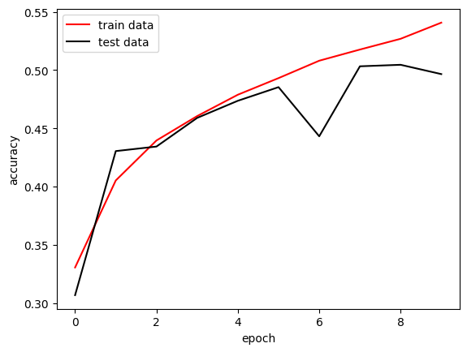

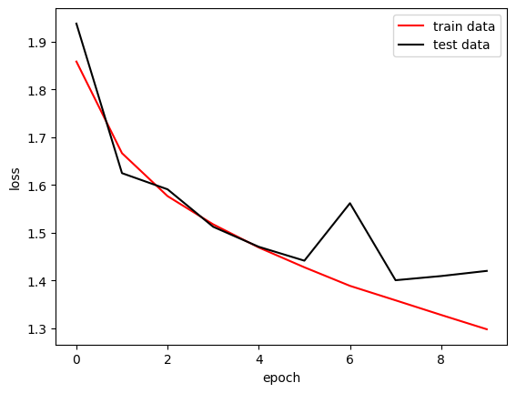

```python
import matplotlib.pyplot as plt
plt.plot(model.history.history['accuracy'], label='train data', color='red')
plt.plot(model.history.history['val_accuracy'], label='test data', color='black')
plt.ylabel('accuracy')
plt.xlabel('epoch')
plt.legend()
plt.show()

plt.plot(model.history.history['loss'], label='train data', color='red')
plt.plot(model.history.history['val_loss'], label='test data', color='black')
plt.ylabel('loss')
plt.xlabel('epoch')
plt.legend()
plt.show()
```

```python
from sklearn.metrics import classification_report
import numpy as np
y_pred = model.predict(x_test)
y_pred = np.argmax(y_pred, axis=1)
y_test2 = np.array(y_test)
y_test2 = np.argmax(y_test2, axis=1)
print(classification_report(y_test2, y_pred))

y_pred = model.predict(x_train)
y_pred = np.argmax(y_pred, axis=1)
y_train2 = np.array(y_train)
y_train2 = np.argmax(y_train2, axis=1)
print(classification_report(y_train2, y_pred))
```

```
              precision    recall  f1-score   support

           0       0.60      0.51      0.55      1000
           1       0.66      0.60      0.63      1000
           2       0.44      0.36      0.40      1000
           3       0.34      0.39      0.37      1000
           4       0.49      0.36      0.42      1000
           5       0.56      0.25      0.34      1000
           6       0.39      0.77      0.52      1000
           7       0.67      0.47      0.55      1000
           8       0.47      0.77      0.58      1000
           9       0.63      0.48      0.55      1000

    accuracy                           0.50     10000
   macro avg       0.53      0.50      0.49     10000
weighted avg       0.53      0.50      0.49     10000

              precision    recall  f1-score   support

           0       0.63      0.53      0.57      5000
           1       0.70      0.69      0.69      5000
           2       0.48      0.38      0.42      5000
           3       0.39      0.45      0.42      5000
           4       0.53      0.42      0.46      5000
           5       0.61      0.27      0.37      5000
           6       0.41      0.78      0.54      5000
           7       0.73      0.54      0.62      5000
           8       0.51      0.82      0.63      5000
           9       0.70      0.55      0.62      5000

    accuracy                           0.54     50000
   macro avg       0.57      0.54      0.53     50000
weighted avg       0.57      0.54      0.53     50000
```

```python
from keras import layers, optimizers
from keras.models import Sequential
import pandas as pd
model = Sequential()
model.add(layers.Dense(1000, input_dim=3072, activation=layers.LeakyReLU(alpha=0.1)))
model.add(layers.Dense(700, activation=layers.LeakyReLU(alpha=0.1)))
model.add(layers.Dense(400, activation=layers.LeakyReLU(alpha=0.1)))
model.add(layers.Dense(100, activation=layers.LeakyReLU(alpha=0.1)))
model.add(layers.Dense(10, activation='softmax'))
opt = optimizers.SGD(learning_rate = 0.02)
model.compile(opt, loss='categorical_crossentropy', metrics=['accuracy'])

x_test = pd.DataFrame(x_test)
x_train = pd.DataFrame(x_train)
y_test = pd.DataFrame(y_test)
y_train = pd.DataFrame(y_train)
model.fit(x_train,y_train, epochs = 10, batch_size = 32, validation_data = (x_test,y_test))
```

```
<keras.callbacks.History at 0x190da7381f0>
```

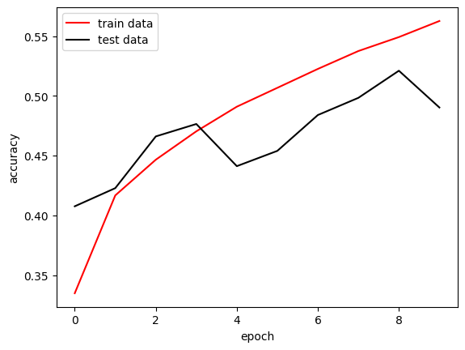

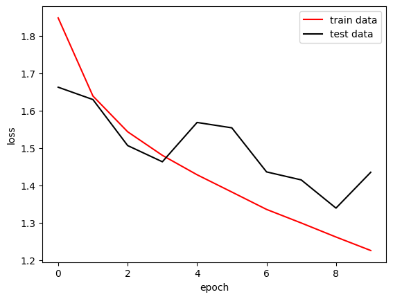

```python
import matplotlib.pyplot as plt
plt.plot(model.history.history['accuracy'], label='train data', color='red')
plt.plot(model.history.history['val_accuracy'], label='test data', color='black')
plt.ylabel('accuracy')
plt.xlabel('epoch')
plt.legend()
plt.show()

plt.plot(model.history.history['loss'], label='train data', color='red')
plt.plot(model.history.history['val_loss'], label='test data', color='black')
plt.ylabel('loss')
plt.xlabel('epoch')
plt.legend()
plt.show()
```

```python
from sklearn.metrics import classification_report
import numpy as np
y_pred = model.predict(x_test)
y_pred = np.argmax(y_pred, axis=1)
y_test2 = np.array(y_test)
y_test2 = np.argmax(y_test2, axis=1)
print(classification_report(y_test2, y_pred))

y_pred = model.predict(x_train)
y_pred = np.argmax(y_pred, axis=1)
y_train2 = np.array(y_train)
y_train2 = np.argmax(y_train2, axis=1)
print(classification_report(y_train2, y_pred))
```

```
              precision    recall  f1-score   support

           0       0.59      0.54      0.57      1000
           1       0.68      0.53      0.60      1000
           2       0.46      0.30      0.36      1000
           3       0.29      0.45      0.35      1000
           4       0.45      0.46      0.45      1000
           5       0.35      0.54      0.42      1000
           6       0.58      0.49      0.53      1000
           7       0.70      0.41      0.52      1000
           8       0.51      0.73      0.60      1000
           9       0.66      0.45      0.53      1000

    accuracy                           0.49     10000
   macro avg       0.53      0.49      0.49     10000
weighted avg       0.53      0.49      0.49     10000

              precision    recall  f1-score   support

           0       0.63      0.59      0.61      5000
           1       0.77      0.62      0.69      5000
           2       0.55      0.35      0.43      5000
           3       0.35      0.52      0.42      5000
           4       0.48      0.52      0.50      5000
           5       0.40      0.61      0.48      5000
           6       0.63      0.55      0.59      5000
           7       0.77      0.49      0.60      5000
           8       0.57      0.78      0.66      5000
           9       0.77      0.53      0.63      5000

    accuracy                           0.55     50000
   macro avg       0.59      0.55      0.56     50000
weighted avg       0.59      0.55      0.56     50000
```

## قسمت دوم)بررسی تاثیر تغییرات مختلف و سوالات

### تاثیر optimizer

Momentum یک اصطلاح است که در الگوریتم gradient discent استفاده میگردد. این الگوریتم یک الگوریتم بهینه سازی است که کار آن، یافتن جهت تندترین شیب در وضعیت فعلی میباشد. پس از یافتن، به سمت آن حرکت میکند و آن را به روز رسانی میکند. با این کار، در هر مرحله مقدار تابعی که باید به حداقل برسد، کاهش می یابد. ولی مشکلی وجود دارد و آن این است که این جهت میتواند در برخی نقاط تابع به شدت تغییر کند در حالیکه بهترین مسیر برای رفتن شامل پیچ های زیادی نیست. پس از momentum استفاده میکنیم یعنی الگوریتم را برای مدتی قبل از اینکه جهت خود را تغییر دهیم، حفظ میکنیم.  
بر اساس سه momentum متفاوت که در پایین تست کرده ایم، متوجه شدیم که با افزایش تکانه، لزوما دقت افزایش نمی یابد. momentum کمک میکند تا گرادیان را تسریع کنیم و اگر مقدار تکانه خیلی کم باشد، این اتفاق خیلی آهسته رخ میدهد. اگر تکانه و نرخ یادگیری را یک مقدار بزرگ قرار دهیم، گام های بزرگتری خواهیم داشت در نتیجه وزن ها به روش صحیح مقداردهی نمیشوند و به مقدار بهینه نمیرسند.

Momentum: 0.5

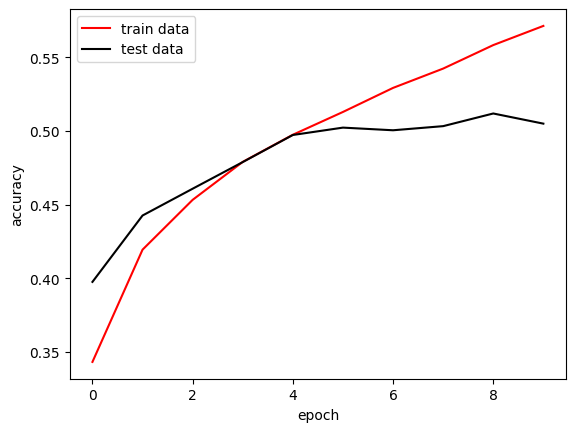

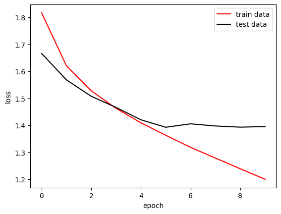

```
              precision    recall  f1-score   support

           0       0.57      0.55      0.56      1000
           1       0.52      0.76      0.62      1000
           2       0.36      0.44      0.40      1000
           3       0.35      0.30      0.32      1000
           4       0.48      0.42      0.45      1000
           5       0.47      0.39      0.43      1000
           6       0.47      0.65      0.55      1000
           7       0.71      0.46      0.56      1000
           8       0.63      0.63      0.63      1000
           9       0.57      0.45      0.50      1000

    accuracy                           0.51     10000
   macro avg       0.51      0.51      0.50     10000
weighted avg       0.51      0.51      0.50     10000

              precision    recall  f1-score   support

           0       0.64      0.60      0.62      5000
           1       0.57      0.84      0.68      5000
           2       0.45      0.53      0.49      5000
           3       0.47      0.40      0.43      5000
           4       0.55      0.49      0.52      5000
           5       0.56      0.44      0.49      5000
           6       0.54      0.72      0.62      5000
           7       0.80      0.57      0.67      5000
           8       0.70      0.68      0.69      5000
           9       0.67      0.55      0.61      5000

    accuracy                           0.58     50000
   macro avg       0.59      0.58      0.58     50000
weighted avg       0.59      0.58      0.58     50000
```

```python
model = Sequential()
model.add(layers.Dense(1000, input_dim=3072, activation=layers.LeakyReLU(alpha=0.1)))
model.add(layers.Dense(700, activation=layers.LeakyReLU(alpha=0.1)))
model.add(layers.Dense(400, activation=layers.LeakyReLU(alpha=0.1)))
model.add(layers.Dense(100, activation=layers.LeakyReLU(alpha=0.1)))
model.add(layers.Dense(10, activation='softmax'))
opt = optimizers.SGD(learning_rate = 0.02, momentum = 0.5)
model.compile(opt, loss='categorical_crossentropy', metrics=['accuracy'])

x_test = pd.DataFrame(x_test)
x_train = pd.DataFrame(x_train)
y_test = pd.DataFrame(y_test)
y_train = pd.DataFrame(y_train)
model.fit(x_train,y_train, epochs = 10, batch_size = 32, validation_data = (x_test,y_test))

plt.plot(model.history.history['accuracy'], label='train data', color='red')
plt.plot(model.history.history['val_accuracy'], label='test data', color='black')
plt.ylabel('accuracy')
plt.xlabel('epoch')
plt.legend()
plt.show()

plt.plot(model.history.history['loss'], label='train data', color='red')
plt.plot(model.history.history['val_loss'], label='test data', color='black')
plt.ylabel('loss')
plt.xlabel('epoch')
plt.legend()
plt.show()

y_pred = model.predict(x_test)
y_pred = np.argmax(y_pred, axis=1)
y_test2 = np.array(y_test)
y_test2 = np.argmax(y_test2, axis=1)
print(classification_report(y_test2, y_pred))

y_pred = model.predict(x_train)
y_pred = np.argmax(y_pred, axis=1)
y_train2 = np.array(y_train)
y_train2 = np.argmax(y_train2, axis=1)
print(classification_report(y_train2, y_pred))
```

Momentum = 0.9

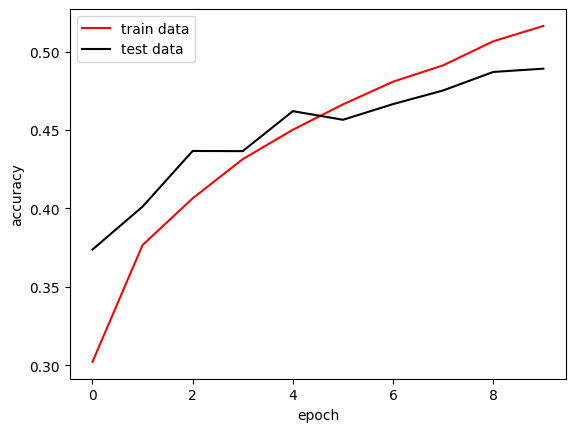

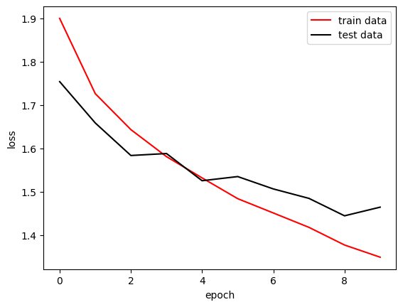

```
              precision    recall  f1-score   support

           0       0.45      0.68      0.54      1000
           1       0.62      0.62      0.62      1000
           2       0.34      0.40      0.37      1000
           3       0.39      0.27      0.31      1000
           4       0.41      0.35      0.38      1000
           5       0.50      0.27      0.35      1000
           6       0.51      0.56      0.54      1000
           7       0.50      0.61      0.55      1000
           8       0.68      0.53      0.59      1000
           9       0.53      0.60      0.56      1000

    accuracy                           0.49     10000
   macro avg       0.49      0.49      0.48     10000
weighted avg       0.49      0.49      0.48     10000

              precision    recall  f1-score   support

           0       0.46      0.68      0.55      5000
           1       0.67      0.69      0.68      5000
           2       0.39      0.43      0.41      5000
           3       0.46      0.33      0.38      5000
           4       0.45      0.39      0.42      5000
           5       0.55      0.29      0.38      5000
           6       0.54      0.60      0.57      5000
           7       0.55      0.68      0.61      5000
           8       0.75      0.57      0.65      5000
           9       0.59      0.67      0.62      5000

    accuracy                           0.53     50000
   macro avg       0.54      0.53      0.53     50000
weighted avg       0.54      0.53      0.53     50000
```

```python
model = Sequential()
model.add(layers.Dense(1000, input_dim=3072, activation=layers.LeakyReLU(alpha=0.1)))
model.add(layers.Dense(700, activation=layers.LeakyReLU(alpha=0.1)))
model.add(layers.Dense(400, activation=layers.LeakyReLU(alpha=0.1)))
model.add(layers.Dense(100, activation=layers.LeakyReLU(alpha=0.1)))
model.add(layers.Dense(10, activation='softmax'))
opt = optimizers.SGD(learning_rate = 0.02, momentum = 0.9)
model.compile(opt, loss='categorical_crossentropy', metrics=['accuracy'])

x_test = pd.DataFrame(x_test)
x_train = pd.DataFrame(x_train)
y_test = pd.DataFrame(y_test)
y_train = pd.DataFrame(y_train)
model.fit(x_train,y_train, epochs = 10, batch_size = 32, validation_data = (x_test,y_test))

plt.plot(model.history.history['accuracy'], label='train data', color='red')
plt.plot(model.history.history['val_accuracy'], label='test data', color='black')
plt.ylabel('accuracy')
plt.xlabel('epoch')
plt.legend()
plt.show()

plt.plot(model.history.history['loss'], label='train data', color='red')
plt.plot(model.history.history['val_loss'], label='test data', color='black')
plt.ylabel('loss')
plt.xlabel('epoch')
plt.legend()
plt.show()

y_pred = model.predict(x_test)
y_pred = np.argmax(y_pred, axis=1)
y_test2 = np.array(y_test)
y_test2 = np.argmax(y_test2, axis=1)
print(classification_report(y_test2, y_pred))

y_pred = model.predict(x_train)
y_pred = np.argmax(y_pred, axis=1)
y_train2 = np.array(y_train)
y_train2 = np.argmax(y_train2, axis=1)
print(classification_report(y_train2, y_pred))
```

Momentum = 0.98

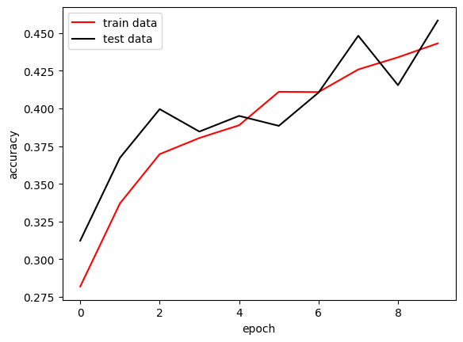

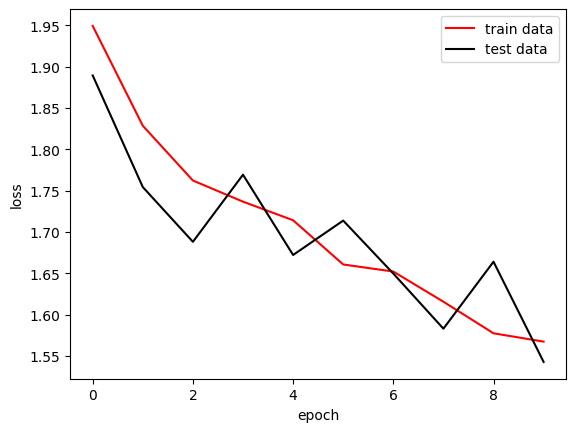

```
              precision    recall  f1-score   support

           0       0.57      0.52      0.54      1000
           1       0.58      0.54      0.56      1000
           2       0.40      0.16      0.23      1000
           3       0.35      0.25      0.29      1000
           4       0.40      0.35      0.37      1000
           5       0.38      0.37      0.38      1000
           6       0.45      0.60      0.51      1000
           7       0.42      0.58      0.49      1000
           8       0.59      0.58      0.59      1000
           9       0.43      0.63      0.51      1000

    accuracy                           0.46     10000
   macro avg       0.46      0.46      0.45     10000
weighted avg       0.46      0.46      0.45     10000

              precision    recall  f1-score   support

           0       0.55      0.49      0.52      5000
           1       0.59      0.57      0.58      5000
           2       0.41      0.17      0.24      5000
           3       0.38      0.26      0.31      5000
           4       0.42      0.37      0.39      5000
           5       0.40      0.39      0.40      5000
           6       0.46      0.60      0.52      5000
           7       0.45      0.64      0.53      5000
           8       0.61      0.61      0.61      5000
           9       0.45      0.66      0.53      5000

    accuracy                           0.47     50000
   macro avg       0.47      0.47      0.46     50000
weighted avg       0.47      0.47      0.46     50000
```

```python
model = Sequential()
model.add(layers.Dense(1000, input_dim=3072, activation=layers.LeakyReLU(alpha=0.1)))
model.add(layers.Dense(700, activation=layers.LeakyReLU(alpha=0.1)))
model.add(layers.Dense(400, activation=layers.LeakyReLU(alpha=0.1)))
model.add(layers.Dense(100, activation=layers.LeakyReLU(alpha=0.1)))
model.add(layers.Dense(10, activation='softmax'))
opt = optimizers.SGD(learning_rate = 0.01, momentum = 0.98)
model.compile(opt, loss='categorical_crossentropy', metrics=['accuracy'])

x_test = pd.DataFrame(x_test)
x_train = pd.DataFrame(x_train)
y_test = pd.DataFrame(y_test)
y_train = pd.DataFrame(y_train)
model.fit(x_train,y_train, epochs = 10, batch_size = 32, validation_data = (x_test,y_test))

plt.plot(model.history.history['accuracy'], label='train data', color='red')
plt.plot(model.history.history['val_accuracy'], label='test data', color='black')
plt.ylabel('accuracy')
plt.xlabel('epoch')
plt.legend()
plt.show()

plt.plot(model.history.history['loss'], label='train data', color='red')
plt.plot(model.history.history['val_loss'], label='test data', color='black')
plt.ylabel('loss')
plt.xlabel('epoch')
plt.legend()
plt.show()

y_pred = model.predict(x_test)
y_pred = np.argmax(y_pred, axis=1)
y_test2 = np.array(y_test)
y_test2 = np.argmax(y_test2, axis=1)
print(classification_report(y_test2, y_pred))

y_pred = model.predict(x_train)
y_pred = np.argmax(y_pred, axis=1)
y_train2 = np.array(y_train)
y_train2 = np.argmax(y_train2, axis=1)
print(classification_report(y_train2, y_pred))
```

در این قسمت از بهینه ساز Adam بهره میبریم.

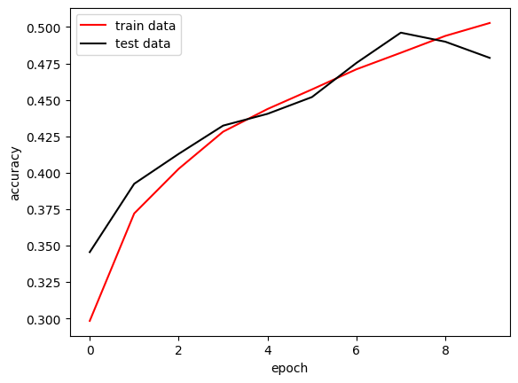

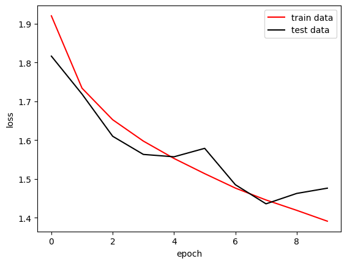

```
              precision    recall  f1-score   support

           0       0.51      0.65      0.57      1000
           1       0.46      0.81      0.59      1000
           2       0.45      0.24      0.32      1000
           3       0.29      0.59      0.39      1000
           4       0.45      0.42      0.44      1000
           5       0.61      0.09      0.16      1000
           6       0.56      0.47      0.51      1000
           7       0.59      0.55      0.57      1000
           8       0.69      0.54      0.61      1000
           9       0.57      0.42      0.48      1000

    accuracy                           0.48     10000
   macro avg       0.52      0.48      0.46     10000
weighted avg       0.52      0.48      0.46     10000

              precision    recall  f1-score   support

           0       0.51      0.64      0.57      5000
           1       0.48      0.85      0.61      5000
           2       0.49      0.25      0.33      5000
           3       0.31      0.63      0.41      5000
           4       0.47      0.46      0.47      5000
           5       0.65      0.09      0.16      5000
           6       0.61      0.50      0.55      5000
           7       0.64      0.60      0.62      5000
           8       0.73      0.55      0.63      5000
           9       0.61      0.47      0.53      5000

    accuracy                           0.51     50000
   macro avg       0.55      0.51      0.49     50000
weighted avg       0.55      0.51      0.49     50000
```

```python
model = Sequential()
model.add(layers.Dense(1000, input_dim=3072, activation=layers.LeakyReLU(alpha=0.1)))
model.add(layers.Dense(700, activation=layers.LeakyReLU(alpha=0.1)))
model.add(layers.Dense(400, activation=layers.LeakyReLU(alpha=0.1)))
model.add(layers.Dense(100, activation=layers.LeakyReLU(alpha=0.1)))
model.add(layers.Dense(10, activation='softmax'))
opt = optimizers.Adam(learning_rate = 0.001)
model.compile(opt, loss='categorical_crossentropy', metrics=['accuracy'])

x_test = pd.DataFrame(x_test)
x_train = pd.DataFrame(x_train)
y_test = pd.DataFrame(y_test)
y_train = pd.DataFrame(y_train)
model.fit(x_train,y_train, epochs = 10, batch_size = 32, validation_data = (x_test,y_test))

plt.plot(model.history.history['accuracy'], label='train data', color='red')
plt.plot(model.history.history['val_accuracy'], label='test data', color='black')
plt.ylabel('accuracy')
plt.xlabel('epoch')
plt.legend()
plt.show()

plt.plot(model.history.history['loss'], label='train data', color='red')
plt.plot(model.history.history['val_loss'], label='test data', color='black')
plt.ylabel('loss')
plt.xlabel('epoch')
plt.legend()
plt.show()

y_pred = model.predict(x_test)
y_pred = np.argmax(y_pred, axis=1)
y_test2 = np.array(y_test)
y_test2 = np.argmax(y_test2, axis=1)
print(classification_report(y_test2, y_pred))

y_pred = model.predict(x_train)
y_pred = np.argmax(y_pred, axis=1)
y_train2 = np.array(y_train)
y_train2 = np.argmax(y_train2, axis=1)
print(classification_report(y_train2, y_pred))
```

### تاثیر تعداد epoch

epoch چرخه ای است که مجموعه داده آموزشی از طریق شبکه عبور می کند. با داشتن تعداد مناسب epoch می توانیم به تعمیم در شبکه خود دست یابیم. در واقع عملکرد شبکه در طبقه بندی نمونه های دیده نشده بهتر می شود. دلیل آنکه از چند epoch استفاده میکنیم این است که gradient descent به مینیموم محلی یا مینیموم گلوبال خود نمیرسد و یکبار آموزش دادن میتواند منجر به underfitting شود.  
از طرف دیگر، اگر تعداد epoch ها را برابر یک مقدار خیلی بزرگ قرار دهیم، ممکن است منجر به overfitting شود، زیرا ما داده ها را چندین بار آموزش می دهیم و مدل ما شروع به مدل سازی نویزهای موجود در داده ها می کند و دقت داده های تست کاهش می یابد. برای جلوگیری از overfitting از روش early stopping کمک می گیریم. در این جهت یک معیار تحت عنوان monitor تعریف میکنیم. به این معیار گفته می شود که اگر پیشرفت داده با توجه به معیار مثلا دقت بعد از مدتی افزایش نداشت از ادامه فرآیند یادگیری شبکه عصبی منصرف شود زیرا از یک جایی به بعد منجر به overfitting میشود.

### تاثیر loss function

- وقتی از MSE استفاده میکنیم که در داده ها توزیع نرمال داشته باشیم. در اینجا ما مجموعه ای از داده های طبقه بندی را داریم در نتیجه این روش مناسب نیست.
- تابع MSE برای طبقه بندی غیر محدب است. به عبارت دیگر، اگر یک مدل طبقه بندی با تابع ضرر MSE آموزش داده شود، تضمینی برای به حداقل رساندن loss function وجود ندارد.

MSE انتخاب خوبی برای رگرسیون خطی میباشد.

```python
model = Sequential()
model.add(layers.Dense(1000, input_dim=3072, activation=layers.LeakyReLU(alpha=0.1)))
model.add(layers.Dense(700, activation=layers.LeakyReLU(alpha=0.1)))
model.add(layers.Dense(400, activation=layers.LeakyReLU(alpha=0.1)))
model.add(layers.Dense(100, activation=layers.LeakyReLU(alpha=0.1)))
model.add(layers.Dense(10, activation='softmax'))
opt = optimizers.Adam(learning_rate = 0.001)
model.compile(opt, loss='mse', metrics=['accuracy'])

x_test = pd.DataFrame(x_test)
x_train = pd.DataFrame(x_train)
y_test = pd.DataFrame(y_test)
y_train = pd.DataFrame(y_train)
model.fit(x_train,y_train, epochs = 10, batch_size = 32, validation_data = (x_test,y_test))
```

```
<keras.callbacks.History at 0x190d901df00>
```

### تاثیر regularization

با قرار دادن drop out از over fitting جلوگیری میشود و دقت داده آموزشی و تستی به یک میزان افزایش می یابد. با توجه به نتایج پایین، میتوان فهمید فاصله میان دقت داده آموزشی و تست نیز کمتر میشود ولی سرعت فرآیند یادگیری کاهش می یابد.

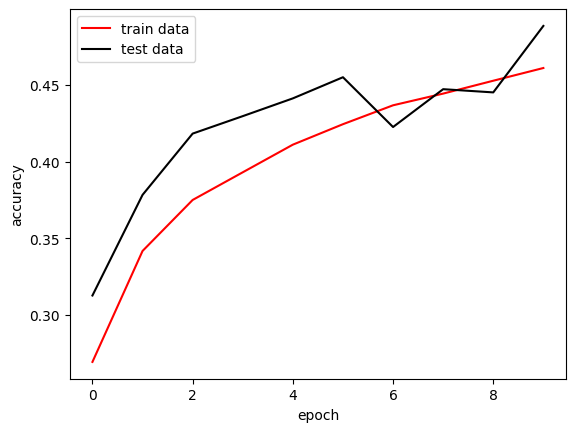

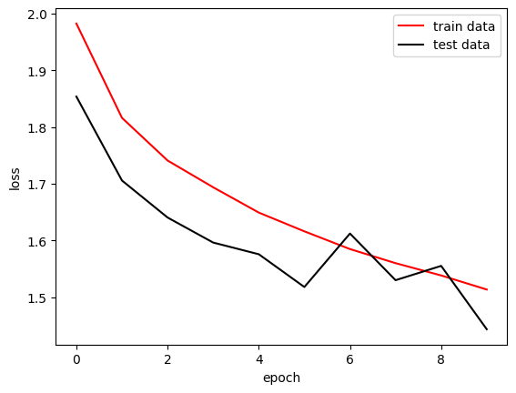

```
              precision    recall  f1-score   support

           0       0.51      0.60      0.56      1000
           1       0.58      0.61      0.59      1000
           2       0.50      0.14      0.21      1000
           3       0.34      0.33      0.34      1000
           4       0.46      0.36      0.41      1000
           5       0.40      0.30      0.35      1000
           6       0.49      0.62      0.55      1000
           7       0.47      0.64      0.54      1000
           8       0.62      0.62      0.62      1000
           9       0.48      0.66      0.56      1000

    accuracy                           0.49     10000
   macro avg       0.49      0.49      0.47     10000
weighted avg       0.49      0.49      0.47     10000

              precision    recall  f1-score   support

           0       0.52      0.60      0.56      5000
           1       0.59      0.63      0.61      5000
           2       0.50      0.14      0.22      5000
           3       0.37      0.35      0.36      5000
           4       0.47      0.38      0.42      5000
           5       0.44      0.33      0.38      5000
           6       0.49      0.61      0.54      5000
           7       0.50      0.67      0.57      5000
           8       0.66      0.64      0.65      5000
           9       0.50      0.70      0.58      5000

    accuracy                           0.51     50000
   macro avg       0.50      0.51      0.49     50000
weighted avg       0.50      0.51      0.49     50000
```

```python
model = Sequential()
model.add(layers.Dense(1000, input_dim=3072, activation=layers.LeakyReLU(alpha=0.1)))
model.add(tensorflow.keras.layers.Dropout(0.1))
model.add(layers.Dense(700, activation=layers.LeakyReLU(alpha=0.1)))
model.add(tensorflow.keras.layers.Dropout(0.1))
model.add(layers.Dense(400, activation=layers.LeakyReLU(alpha=0.1)))
model.add(tensorflow.keras.layers.Dropout(0.1))
model.add(layers.Dense(100, activation=layers.LeakyReLU(alpha=0.1)))
model.add(tensorflow.keras.layers.Dropout(0.1))
model.add(layers.Dense(10, activation='softmax'))
opt = optimizers.Adam(learning_rate = 0.001)
model.compile(opt, loss='categorical_crossentropy', metrics=['accuracy'])

x_test = pd.DataFrame(x_test)
x_train = pd.DataFrame(x_train)
y_test = pd.DataFrame(y_test)
y_train = pd.DataFrame(y_train)
model.fit(x_train,y_train, epochs = 10, batch_size = 32, validation_data = (x_test,y_test))

plt.plot(model.history.history['accuracy'], label='train data', color='red')
plt.plot(model.history.history['val_accuracy'], label='test data', color='black')
plt.ylabel('accuracy')
plt.xlabel('epoch')
plt.legend()
plt.show()

plt.plot(model.history.history['loss'], label='train data', color='red')
plt.plot(model.history.history['val_loss'], label='test data', color='black')
plt.ylabel('loss')
plt.xlabel('epoch')
plt.legend()
plt.show()

y_pred = model.predict(x_test)
y_pred = np.argmax(y_pred, axis=1)
y_test2 = np.array(y_test)
y_test2 = np.argmax(y_test2, axis=1)
print(classification_report(y_test2, y_pred))

y_pred = model.predict(x_train)
y_pred = np.argmax(y_pred, axis=1)
y_train2 = np.array(y_train)
y_train2 = np.argmax(y_train2, axis=1)
print(classification_report(y_train2, y_pred))
```